# DATA ANALYSIS OF THE RARE SOAY SHEEP

### Testing for autocorrelation

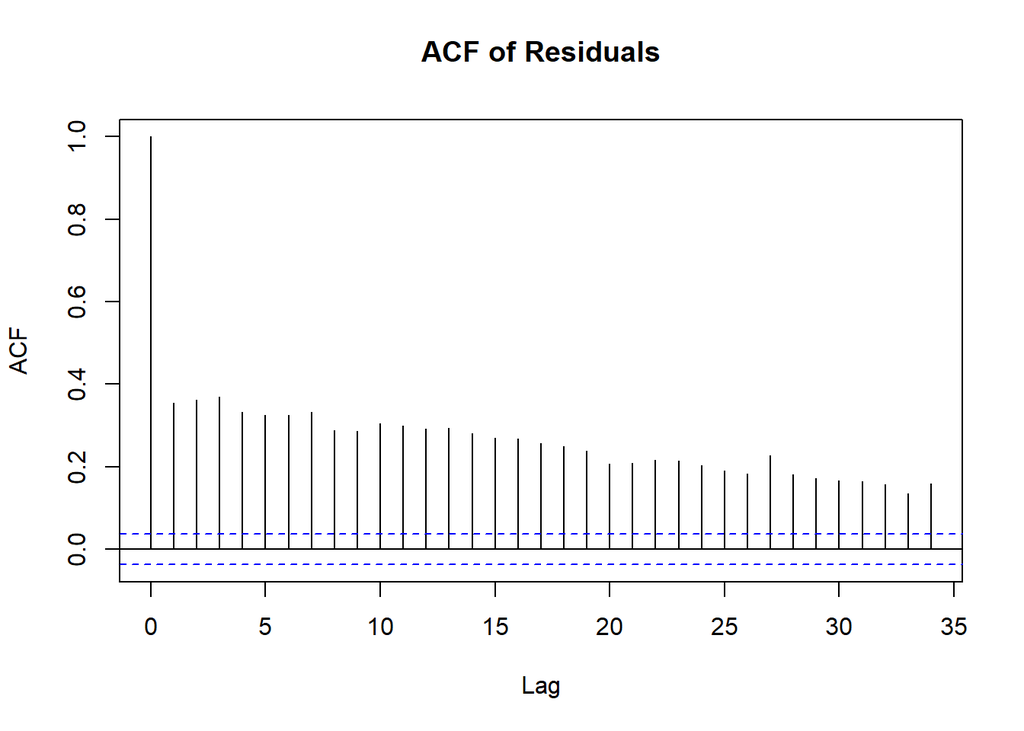

```r
# Testing autocorrelation
residuals_model_4 <- residuals(model4)

# Autocorrelation Function (ACFmodel4# Autocorrelation Function (ACF) Plot
acf(residuals_model_4, main = "ACF of Residuals")
```

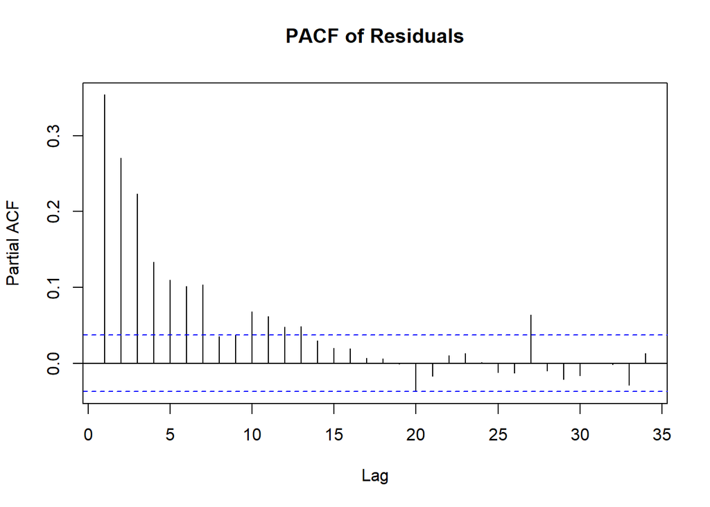

```r
# Partial Autocorrelation Function (PACF) Plot
pacf(residuals_model_4, main = "PACF of Residuals")
```

```r
# Ljung-Box Test
ljung_box_test <- Box.test(residuals_model_4, lag = 35, type = "Ljung-Box")
print(ljung_box_test)
```

```
##
##  Box-Ljung test
##
## data:  residuals_model_4
## X-squared = 6434.7, df = 35, p-value < 2.2e-16
```

```r
#add the predicted values from the model
predicted_values <- predict(model4, type = "response")

#dataframe to have predicted and observed values
fit_data <- data.frame("predicted" = predicted_values,
                       "observed" = alternative$weight)
```

Model assessment shows that the model does a good job

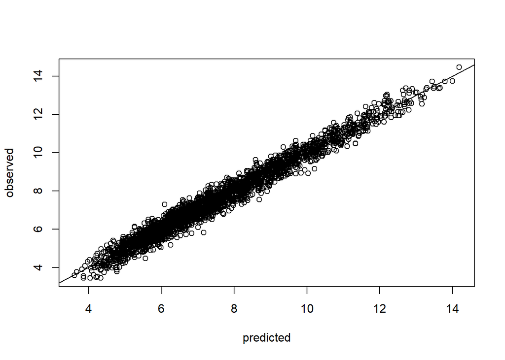

```r
#to plot predicted and observed values of model
plot(fit_data)
abline(0,1)
```

```r
## reshape the outputs of the model into a tidy format:
tidied_model_data <- broom.mixed::tidy(model4, conf.int = TRUE) %>%
  ##clean up the random effect names
  mutate(term=ifelse(grepl("sd__(Int",term,
                           fixed=TRUE),
                               paste(group,term,sep="."),
                               term))
```

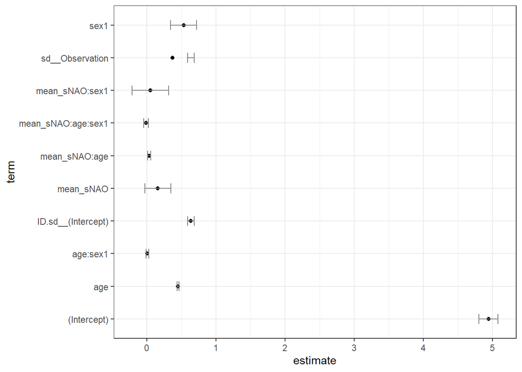

```r
##plot it
ggplot(tidied_model_data, aes(x=estimate, y=term)) +
  geom_point() +
  geom_errorbar(aes(xmin=conf.low, xmax=conf.high),
              width=0.3,
              col="grey50") +
  theme_bw()
```

Tidy data for exploring the fixed effects.

```r
##filter and sort the data
sorted_data <-
  tidied_model_data %>%
  filter(effect=="fixed") %>%
  filter(term!="(Intercept)") %>%
  mutate(term=factor(term, levels = rev(term)))
```

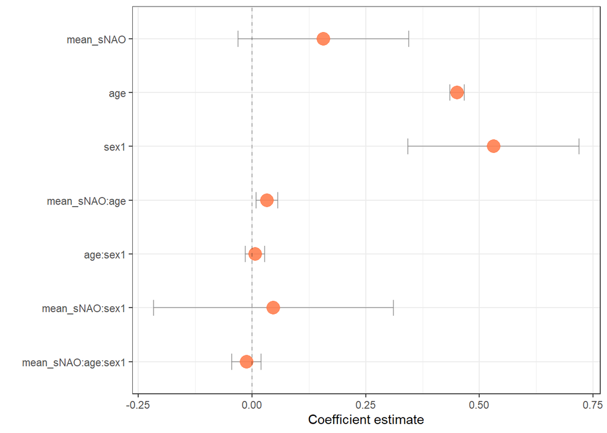

```r
##plot it out
ggplot(sorted_data, aes(x=estimate, y=term)) +
  geom_errorbar(aes(xmin=conf.low, xmax=conf.high),
              width=0.3,
              col="grey50",
              alpha=0.7) +
  geom_point(col="coral", size=5, alpha=0.9) +
  geom_vline(xintercept=0, lty="dashed", alpha=0.3) +
  theme_bw() +
  ylab("") +
  xlab("Coefficient estimate")
```

### Predicting the values with the model we have

```r
#To predict the data
library(ggeffects)
my_df1 <- ggpredict(model4, terms=c("age", "mean_sNAO","sex"))
```

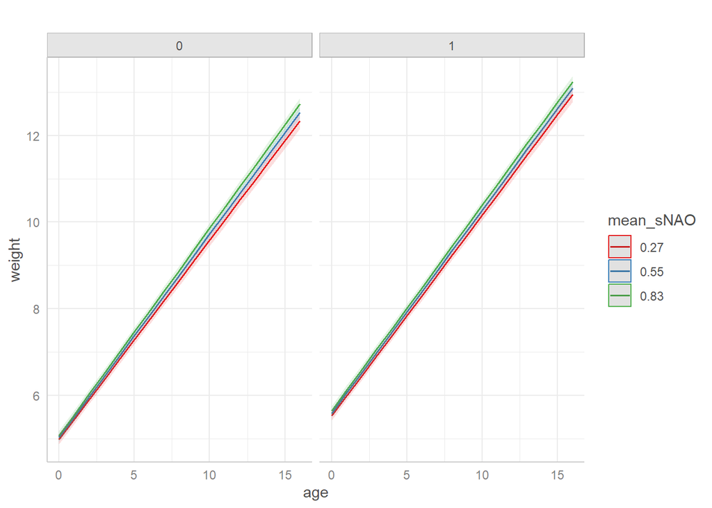

```r
##plot the results!
plot(my_df1) +
  ylab("weight") +
  ggtitle("")
```

```r
ggpredict(model4,
          terms=c("age[15]","mean_sNAO[1.02]","sex[0]"))
```

```
## # Predicted values of weight
##
## age | Predicted |         95% CI
## --------------------------------
##  15 |     12.37 | [12.21, 12.53]
##
## Adjusted for:
## * ID = NA (population-level)
```

```r
ggpredict(model4,
          terms=c("age[15]","mean_sNAO[1.02]","sex[1]"))
```

```
## # Predicted values of weight
##
## age | Predicted |         95% CI
## --------------------------------
##  15 |     12.87 | [12.71, 13.03]
##
## Adjusted for:
## * ID = NA (population-level)
```

# Conclusion

From predicted results, we see that though we considered the same age and mean_sNAO, the male(1) weighs more than female(0) The plot predicts that the weight of the sheep is affected by summer NAO and its internal factors such as age, sex and individuality